# ex4: NP regression: NW(and glkerns, lokerns), LP, SS

Log return of bmw stock.

$X_t = log(Pt/Pt-1)=sigma_t * epsilon_t, sigma_t^2 = v(Xt-1)$

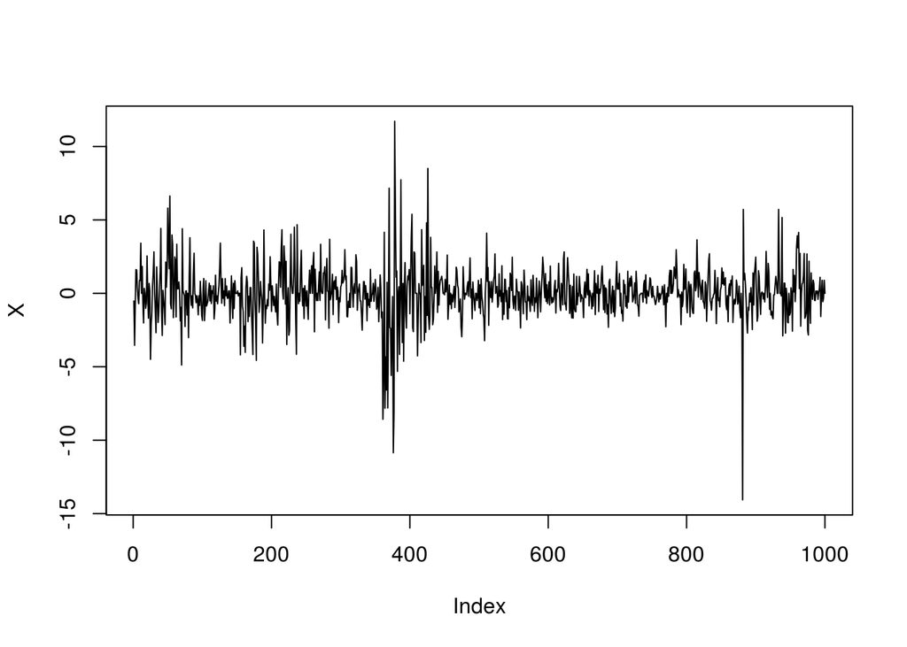

```r
bmwlr <- scan("http://stat.ethz.ch/Teaching/Datasets/bmw.dat") # X[1:1000]
X <- bmwlr
# plot the things out to have a feel
plot(X, type="l")
```

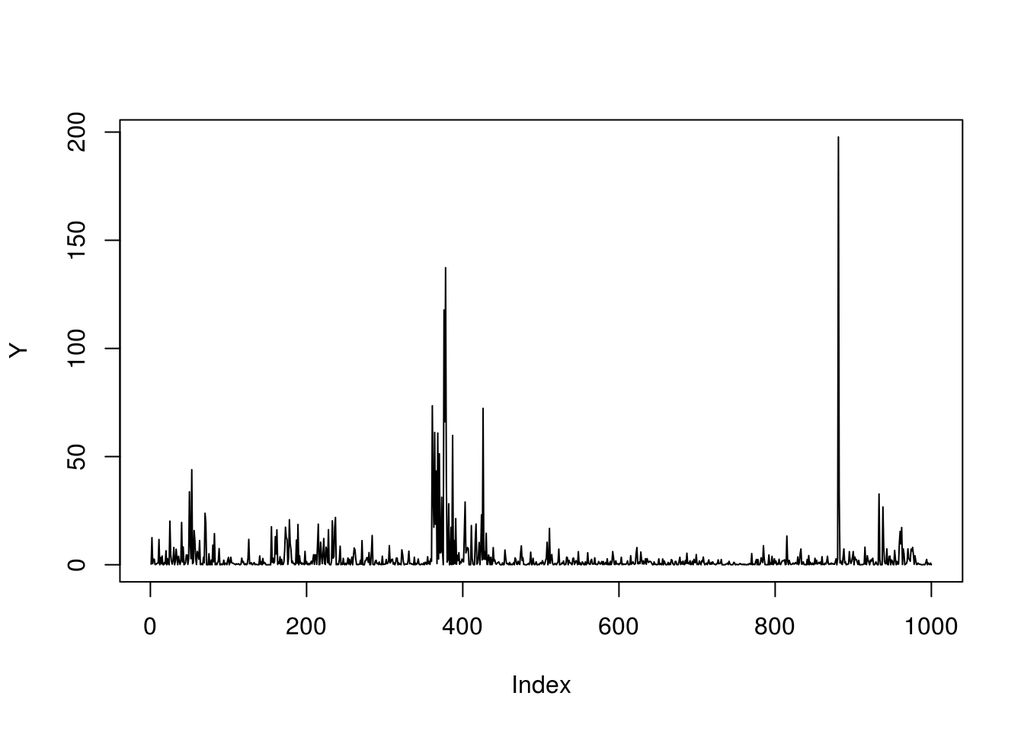

```r
Y <- X^2 # Y = X^2 = v(Xt-1) + eta
plot(Y, type="l")
```

## a) autocorrelation functions

need to use the `acf` function, let’s have a try first:

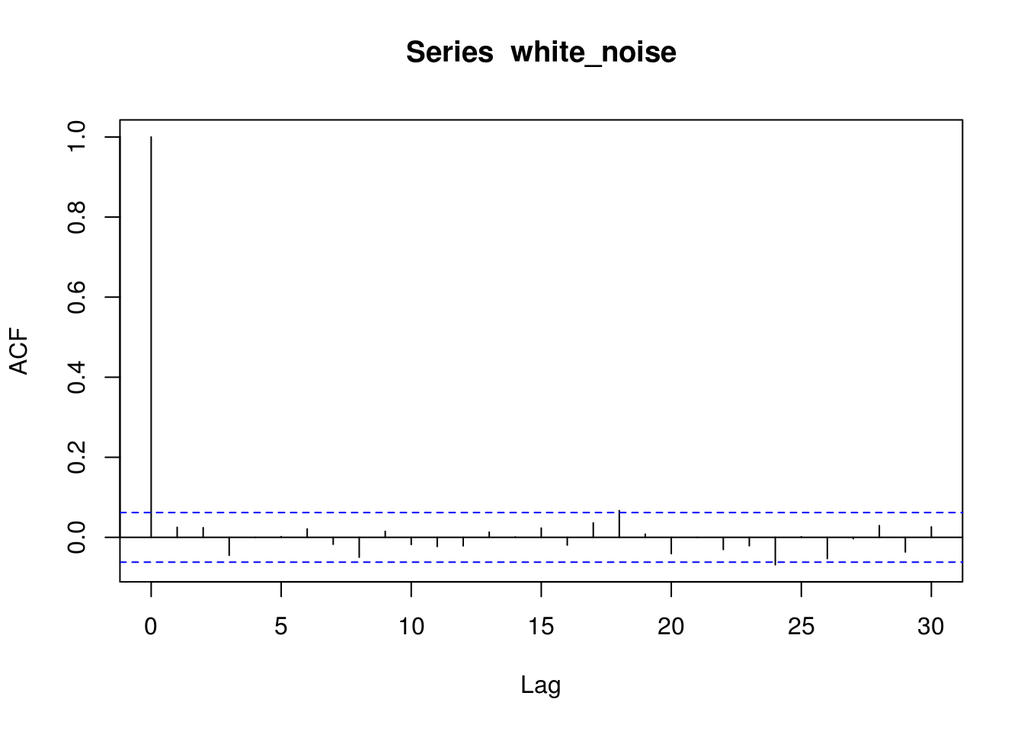

```r
white_noise <- rnorm(1000)
acf(white_noise)
```

So the acf plot give the corelation values for different lags. ex. the value of acf(X) at lag=1 is the corelation between Xt and Xt-1 . We see that if X is indp, `acf(X)` will be 0 for lag>0.

Let’s plot the acf for X and X2:

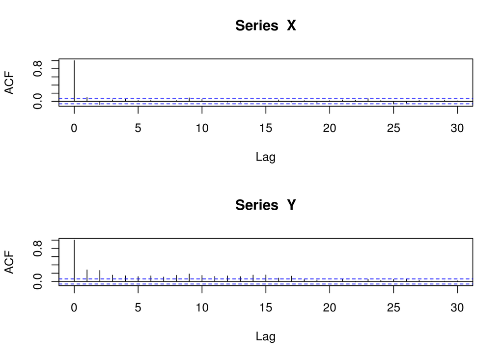

```r
par(mfrow=c(2,1))
acf(X)
acf(Y)
```

## b) fit funciton v() via NW, LP, SS

Yt = Xt^2 = v(Xt-1) + eta_t can only fit for Y[2:1000] because we don’t have X[0], ie we need to feed `x=X[1:999], y=Y[2:1000]` to smoothers.

```r
x <- X[-length(X)]
y <- Y[-1]
fit_lp <- loess(y~x, span = 0.75)
edf <- fit_lp$trace.hat # equivalent deg freedom for lp fit
fit_ss <- smooth.spline(x, y, df=edf) # use the same df for spline fit
```

ksmooth internally reorder its x input in increasing order, to recover it:

```r
fit_nw <- ksmooth(x, y, bandwidth=3.54, x.points=x) # use x.points to get fitted value at design pts
ox <- order(x)
fit_nw$x <- fit_nw$x[order(ox)]
fit_nw$y <- fit_nw$y[order(ox)]
```

**to get fitted values at design points**:

```r
fitted_lp <- fitted(fit_lp)
fitted_ss <- fitted(fit_ss)
fitted_nw <- fit_nw$y
```

**to get the fitted values at other points**:

```r
newx <- seq(-15, 15, length=1000)
fittednew_lp <- predict(fit_lp, newdata = newx)
fittednew_ss <- predict(fit_ss, x=newx)$y # this predict is different from the above !
# see: predict.loess and predict.smooth.spline in help!
fittednew_nw <- ksmooth(x, y,kernel="normal", bandwidth=3.54, x.points=newx)$y
```

### compare the 3 smoothers

```r
summary(x)
```

```
##      Min.   1st Qu.    Median      Mean   3rd Qu.      Max.
## -14.06000  -0.77890   0.00000   0.02376   0.79200  11.72000
```

```r
summary(y)
```

```
##     Min.  1st Qu.   Median     Mean  3rd Qu.     Max.
##   0.0000   0.1201   0.6236   3.2740   2.4530 197.7000
```

plot the fit for whole data range and fit for only central region.

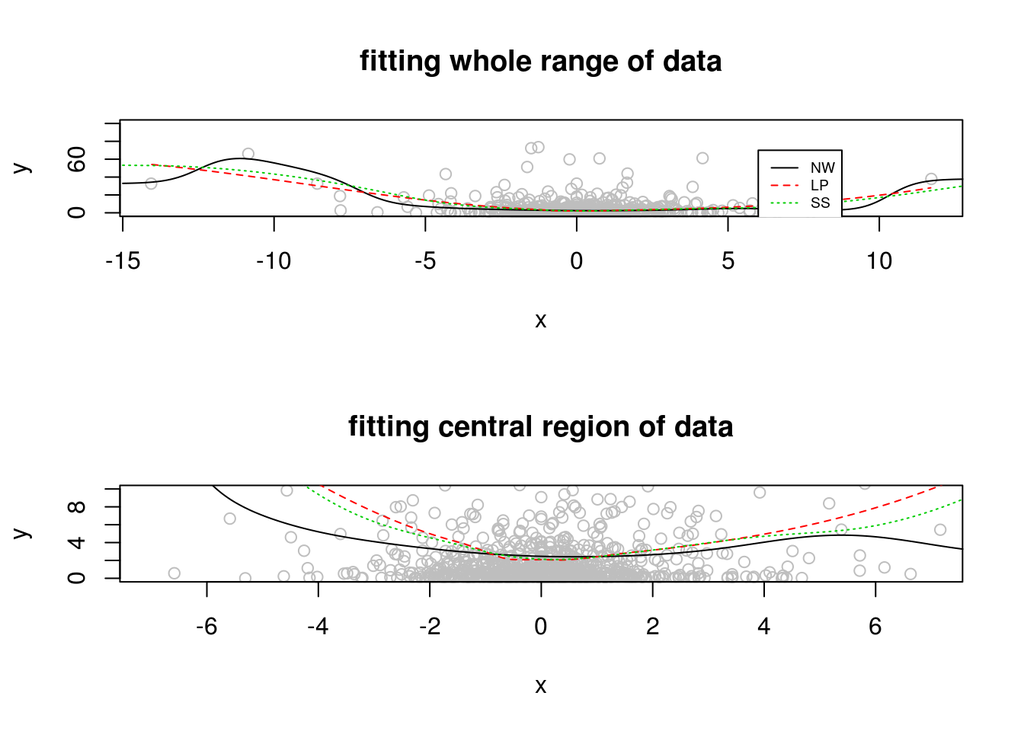

```r
par(mfrow=c(2,1))
plot(x,y, main="fitting whole range of data", col="gray", ylim=c(0,100))
lines(newx, fittednew_nw, lty=1, col=1)
lines(newx, fittednew_lp, lty=2, col=2)
lines(newx, fittednew_ss, lty=3, col=3)
legend(6, 70, legend = c("NW", "LP", "SS"), lty=1:3, col=1:3, cex=0.6)

# plot only central region (xlim=7, ylim=10)
plot(x,y, main="fitting central region of data", col="gray", xlim=c(-7,7), ylim=c(0,10))
lines(newx, fittednew_nw, lty=1, col=1)
lines(newx, fittednew_lp, lty=2, col=2)
lines(newx, fittednew_ss, lty=3, col=3)
legend(6, 70, legend = c("NW", "LP", "SS"), lty=1:3, col=1:3, cex=0.6)
```

remarks: >No clear function pattern is visible, a slight U-shape is noticeable: large returns on the previous day leads to large volalities on next day. NW is determined by few points, hence its poor fit. LP and SS are smoother.

### check model assumption

- residual VS time plot ==> *we see the violation of indep assumption of residuals.*

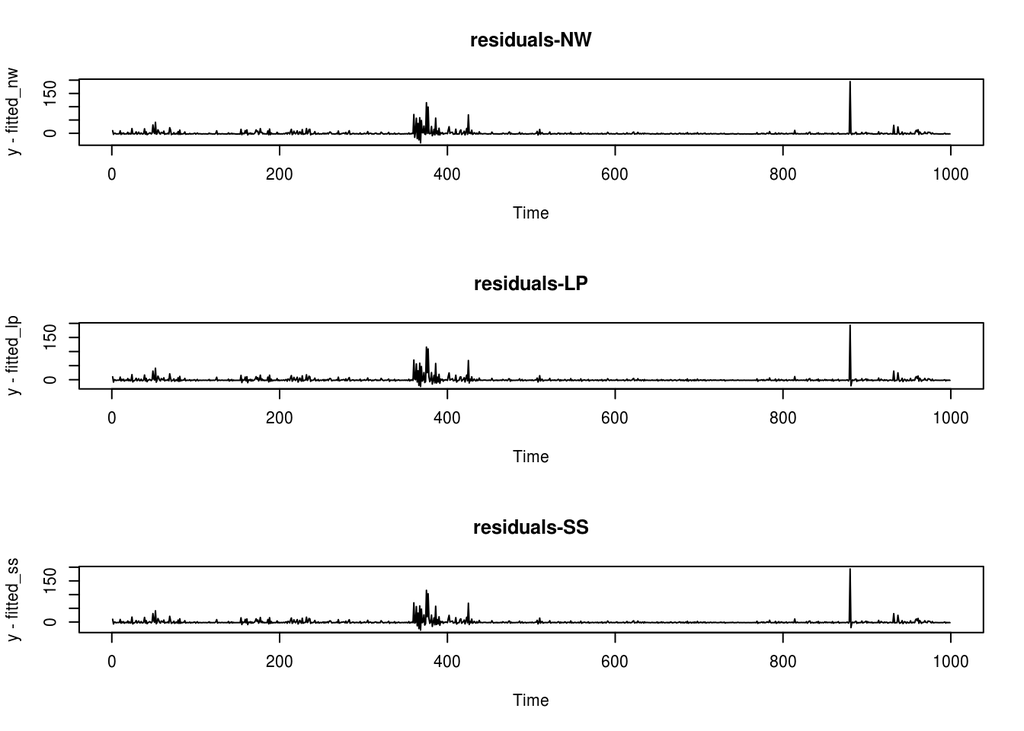

```r
par(mfrow=c(3,1))
# plot.ts is just plot(y-fitted_nw, main="residuals-NW", type="l"), with xlb="Time"
plot.ts(y-fitted_nw, main="residuals-NW")
plot.ts(y-fitted_lp, main="residuals-LP")
plot.ts(y-fitted_ss, main="residuals-SS")
```

- Tukey-Anscombe plot

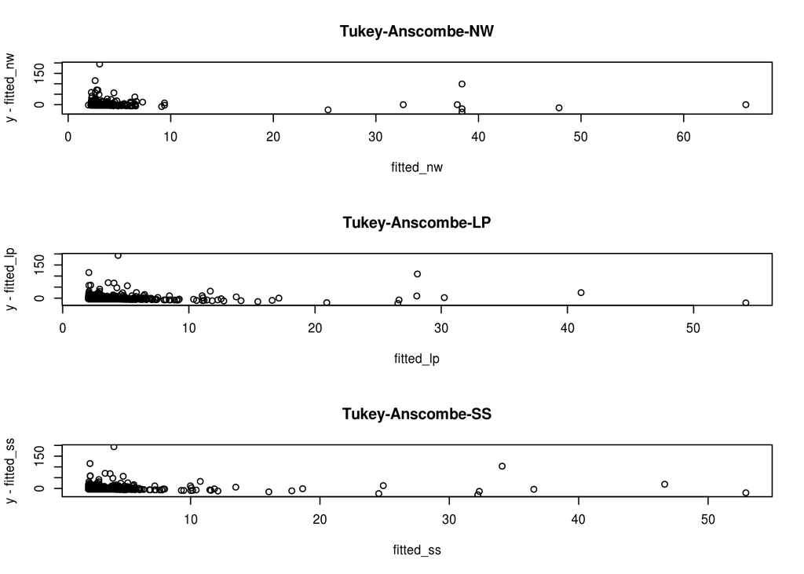

```r
par(mfrow=c(3,1))
# plot.ts is just plot(y-fitted_nw, main="residuals-NW", type="l"), with xlb="Time"
plot(fitted_nw, y-fitted_nw, main="Tukey-Anscombe-NW")
plot(fitted_lp, y-fitted_lp, main="Tukey-Anscombe-LP")
plot(fitted_ss, y-fitted_ss, main="Tukey-Anscombe-SS")
```

==> large outliers

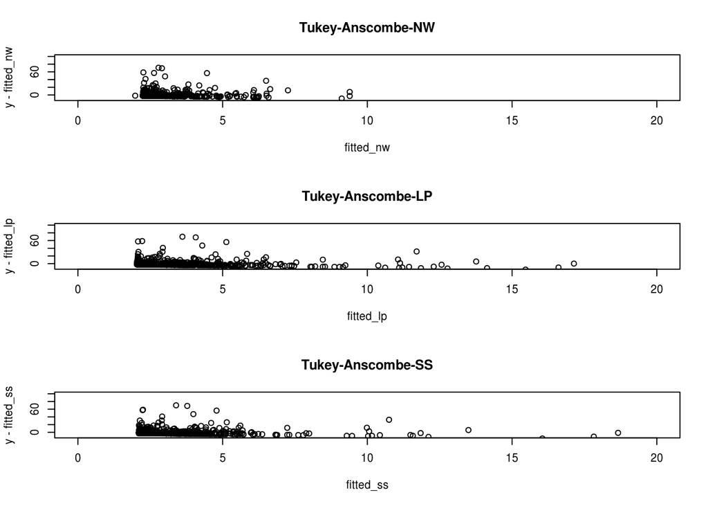

```r
par(mfrow=c(3,1))
# plot.ts is just plot(y-fitted_nw, main="residuals-NW", type="l"), with xlb="Time"
plot(fitted_nw, y-fitted_nw, main="Tukey-Anscombe-NW", ylim=c(-10,100), xlim=c(0,20))
plot(fitted_lp, y-fitted_lp, main="Tukey-Anscombe-LP", ylim=c(-10,100), xlim=c(0,20))
plot(fitted_ss, y-fitted_ss, main="Tukey-Anscombe-SS", ylim=c(-10,100), xlim=c(0,20))
```

- plot estimated volality (sqrt of the fitted value – volality is s.d., not variance)

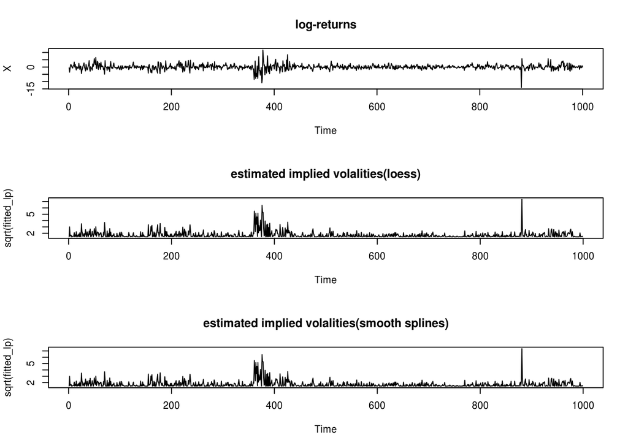

```r
par(mfrow=c(3,1))
plot.ts(X, main="log-returns")
plot.ts(sqrt(fitted_lp), main="estimated implied volalities(loess)")
plot.ts(sqrt(fitted_lp), main="estimated implied volalities(smooth splines)")
```

3. fit the function with global/local opt bandwidth (glkerns and lokerns) have a look at the documentation for glkerns/lokerns –> fitted value at design points = fitted(fit), and the x.out parameter should be NULL fitted value at other points (x.out parameter) = fit$est.

==> to get the design pts and other pts, we need to construct 2 fits!!

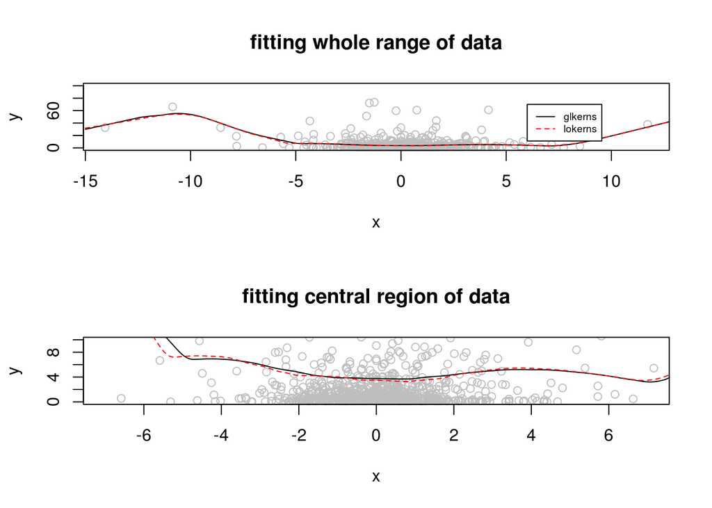

```r
# install.packages("lokern")
library(lokern)
fit_glk <- glkerns(x,y, is.rand=F, hetero=F, x.out=newx)
fit_lok <- lokerns(x,y, is.rand=F, hetero=F, x.out=newx)

par(mfrow=c(2,1))
plot(x,y, main="fitting whole range of data", col="gray", ylim=c(0,100))
lines(newx, fit_glk$est, lty=1, col=1)
lines(newx, fit_lok$est, lty=2, col=2)
legend(6, 70, legend = c("glkerns", "lokerns"), lty=1:2, col=1:2, cex=0.6)

plot(x,y, main="fitting central region of data", col="gray", xlim=c(-7,7),ylim=c(0,10))
lines(newx, fit_glk$est, lty=1, col=1)
lines(newx, fit_lok$est, lty=2, col=2)
```

### residual-time plot ==> indp assumption is violated

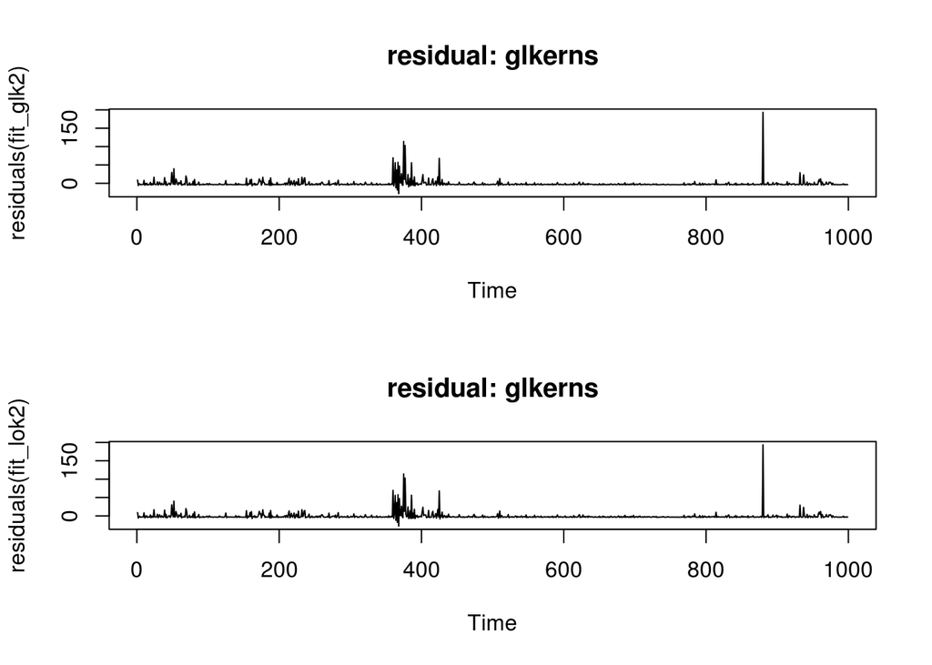

```r
fit_glk2 <- glkerns(x,y, is.rand=F, hetero=F)
fit_lok2 <- lokerns(x,y, is.rand=F, hetero=F)
par(mfrow=c(2,1))
plot.ts(residuals(fit_glk2), main="residual: glkerns") # equivalent to: plot.ts(y-fit_glk2$est[order(ox)])
plot.ts(residuals(fit_lok2), main="residual: glkerns")
```

### plot local bandwidth

in documentation: fit$bandwidth = local bandwidth array

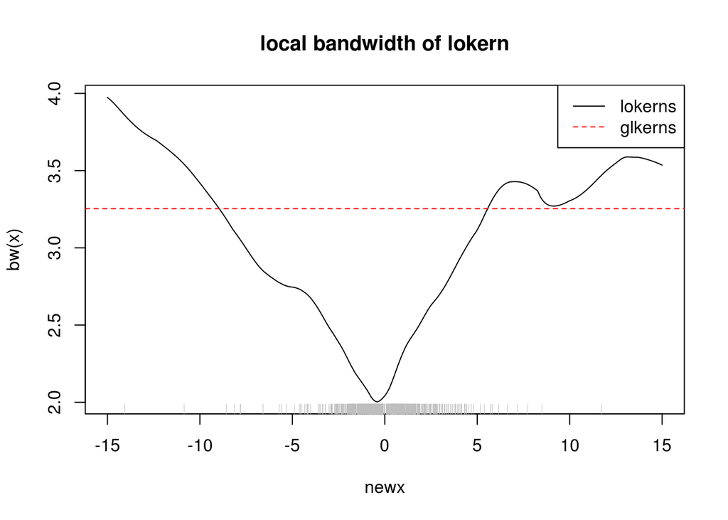

```r
par(mfrow=c(1,1))
plot(newx, fit_lok$bandwidth, type="l",main="local bandwidth of lokern", ylab="bw(x)")
abline(h=fit_glk$bandwidth, col=2, lty=2) # golbal bw
legend("topright", legend = c("lokerns", "glkerns"), lty=1:2, col=1:2)
rug(x, col="gray")
```

remark: >the bandwidth is a function of x, in regions with many data points the local bw is small, in regions where data is sparse the local-bw is large.